# ExtraaLearn Project

## Building a Gradient Boosting model

```python
# Importing the AdaBoostClassifier and GradientBoostingClassifier [Boosting]

# AdaBoostCLassifier:
  #Adaptive Boosting - starts with a Decision tree simple model.
  #Iterative training.
  #Weights for samples.
  #Weights for learners (Better performing Decision Tree models).
  #Combining predictions (based on prediction weighted by its importance).
  # Less prone to overfitting than Gradient Boosting.(sometimes)

# GradientBoostingClassifier:
  # Sequential - builds Decision tree model sequentially.
  # Fits to residual - Each trying to correct errors or the previous ones.
  # Adjusts the learning rate.
  # More flexible than Adaboost, can be prone to overfitting.


from sklearn.ensemble import AdaBoostClassifier, GradientBoostingClassifier

# Adaboost Classifier
adaboost_model = AdaBoostClassifier(random_state = 1)

#GradientBoosting Classifier - #random_state - algorithm input remain same.
gradboost_model = GradientBoostingClassifier(random_state=1)

# Fitting the model
adaboost_model.fit(X_train, y_train)

# Fitting the gradient model
gradboost_model.fit(X_train, y_train)
```

```
GradientBoostingClassifier(random_state=1)
```

```
              precision    recall  f1-score   support

           0       0.86      0.90      0.88      2264
           1       0.74      0.64      0.69       964

    accuracy                           0.83      3228
   macro avg       0.80      0.77      0.78      3228
weighted avg       0.82      0.83      0.82      3228
```

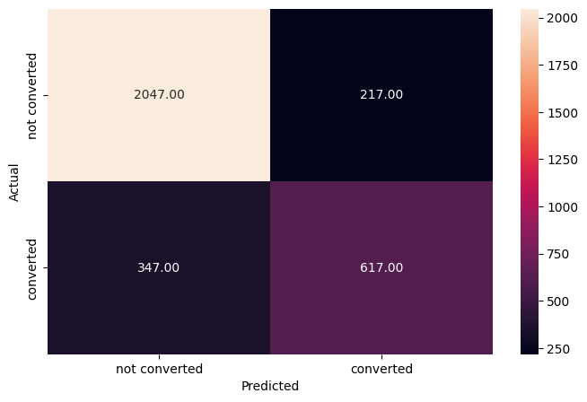

```python
from sklearn.ensemble import AdaBoostClassifier, GradientBoostingClassifier

y_pred_train_adab = adaboost_model.predict(X_train)
metrics_score(y_train, y_pred_train_adab)
```

```
              precision    recall  f1-score   support

           0       0.86      0.90      0.88       971
           1       0.73      0.65      0.69       413

    accuracy                           0.82      1384
   macro avg       0.79      0.77      0.78      1384
weighted avg       0.82      0.82      0.82      1384
```

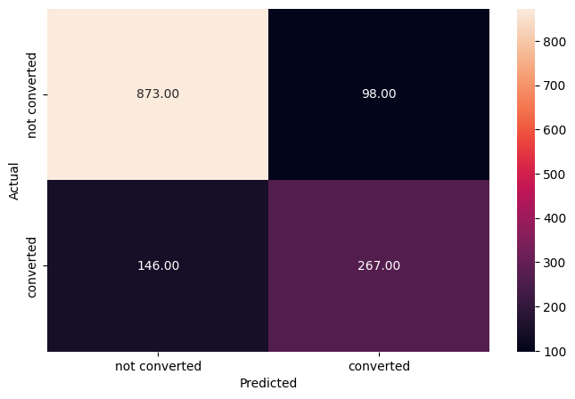

```python
y_pred_test_adab = adaboost_model.predict(X_test)
metrics_score(y_test, y_pred_test_adab)
```

Observation: Adaptive Boosting algorithm

- Performance of the model is good.
- Model is able to generalize better with the recall score.

```
              precision    recall  f1-score   support

           0       0.90      0.93      0.92      2264
           1       0.83      0.77      0.80       964

    accuracy                           0.88      3228
   macro avg       0.86      0.85      0.86      3228
weighted avg       0.88      0.88      0.88      3228
```

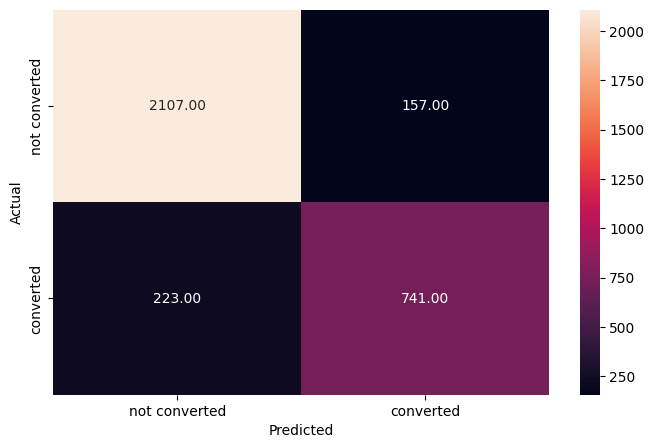

```python
#Gradient Boosting mode predict
y_pred_train_grad = gradboost_model.predict(X_train)
metrics_score(y_train, y_pred_train_grad)
```

```
              precision    recall  f1-score   support

           0       0.90      0.91      0.91       971
           1       0.79      0.75      0.77       413

    accuracy                           0.87      1384
   macro avg       0.84      0.83      0.84      1384
weighted avg       0.86      0.87      0.86      1384
```

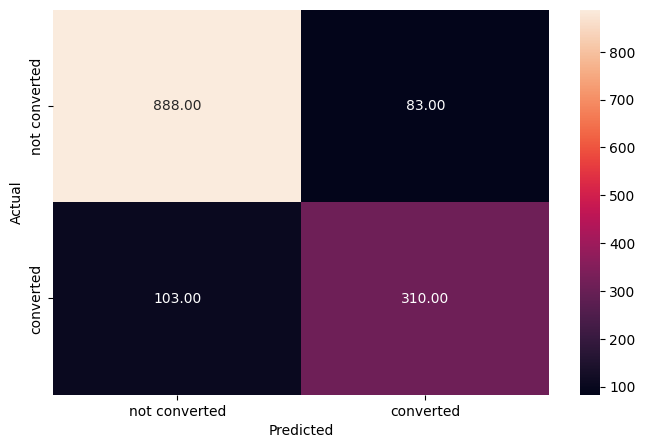

```python
#GradientBoost Train 0.82      0.78      0.80
#GradientBoost Test  0.77      0.75      0.76

y_pred_test_grad = gradboost_model.predict(X_test)
metrics_score(y_test, y_pred_test_grad)
```

Observation: Gradient Boosting

- Gradient Boosting model performance is good.
- Model is able to generalize better with the recall score.

### XGBoost

- XGBoost stands for Extreme Gradient Boosting.
- XGBoost is a tree-based ensemble machine learning technique that improves prediction power and performance by improvising on the Gradient Boosting framework and incorporating reliable approximation algorithms.

```python
#Installing the xgboost library using the 'pip' command.
!pip install xgboost
```

```python
import xgboost
xgboost.__version__
```

```
'3.0.4'
```

```python
# from sklearn.model_selection import train_test_split
# X_train, X_test, y_train, y_test = train_test_split(df.drop(columns=['status']), df['status'], test_size=0.3, random_state=42, stratify= df['status'])

# refer to the above code.
# print(type(y_train)) #pandas <class 'pandas.core.series.Series'>
# print(type(y_test)) #pandas <class 'pandas.core.series.Series'>
# print(type(X_train.shape)) #tuple (3228, 18)
# print(type(y_train.shape)) # tuple (3228,)

# print(X_train.head()) #  (3228, 18); 3228 records having 18 input variables.
# print(y_train.head()) # type tuple. (1384,) records - refer above comment.
```

```python
# XGBClassifier is a class in the xgboost library that implements the Extreme Gradient Boosting
# algorithm for classification tasks.
# It's based on the Gradient Boosting framework but includes several enhancements for
# performance and accuracy, such as regularization, handling missing values, and parallel processing.

# Essentially, it builds an ensemble of decision trees sequentially, where each new tree tries to correct the
# errors of the previous ones.
# This process is optimized to be highly efficient and effective, making XGBoost a popular choice for
# many machine learning challenges, especially when dealing with structured data and aiming for high predictive
# accuracy.
```

```
              precision    recall  f1-score   support

           0       0.99      0.99      0.99      2264
           1       0.99      0.99      0.99       964

    accuracy                           0.99      3228
   macro avg       0.99      0.99      0.99      3228
weighted avg       0.99      0.99      0.99      3228
```

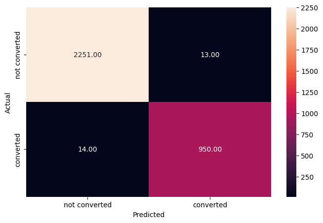

```
              precision    recall  f1-score   support

           0       0.89      0.90      0.89       971
           1       0.76      0.73      0.74       413

    accuracy                           0.85      1384
   macro avg       0.82      0.81      0.82      1384
weighted avg       0.85      0.85      0.85      1384
```

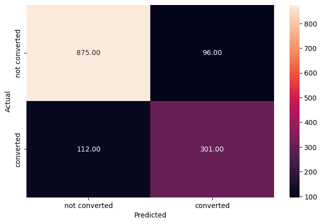

```python
# Importing the XGBClassifier from the xgboost library
from xgboost import XGBClassifier

# XGBoost Classifier
xgb = XGBClassifier(random_state = 1, eval_metric = 'logloss')

# Fitting the model
xgb.fit(X_train,y_train)

#predict training input
y_pred_train_xgb = xgb.predict(X_train)
metrics_score(y_train, y_pred_train_xgb)

#predict test input
y_pred_test_xgb = xgb.predict(X_test)
metrics_score(y_test, y_pred_test_xgb)
```

Observation:

```python
# from sklearn.metrics import accuracy_score, confusion_matrix, classification_report

# help(accuracy_score)

# from sklearn.metrics import recall_score
# help(recall_score)


# parameter - average = 'macro' - applicable for metrics precision/recall/f1score

# average = 'macro': This parameter specifies how to calculate the average recall for multiclass classification problems.
# In your case, although it's a binary classification problem (Attrition or Not Attrition), average='macro' is still a valid option.
# When average='macro', the recall is calculated independently for each class (Attrition and Not Attrition), and then the unweighted average of
# these per-class recall scores is taken. This means that the recall for each class contributes equally to the overall macro average recall,
# regardless of the number of instances in each class.
```

## Model Performance evaluation and improvement

```python
# xgboost XGBClassifier tuning
from sklearn.model_selection import GridSearchCV
from sklearn.metrics import recall_score

# from sklearn.metrics import accuracy_score

#reference hyperparameters
# https://xgboost.readthedocs.io/en/stable/python/python_api.html#xgboost.XGBClassifier

parameters_xgbc = {
    "n_estimators" : [100, 250, 500],
    "learning_rate" : [0.01, 0.05, 0.1],
    "max_depth" : np.arange(3, 7, 1), # 3, 4, 5, 6
    # above is partly selected features from gemini

    ## Below is from my understanding
    "booster" : ['gbtree'],
    "tree_method" : ['exact'],
    "random_state" : [2]
}


#XGB - optimized, highly effective especially for structure data, aiming for high predictive accuracy
#below code uses sklearn metric - recall -> TP/(TP + FN); precision -> TP/TP+FP; accuracy -> TP+TN/(TP+TN+FP+FN);
scorer = metrics.make_scorer(recall_score, pos_label = 1)


gridCV = GridSearchCV(xgb, parameters_xgbc, scoring = scorer, cv = 5)
gridCV = gridCV.fit(X_train, y_train)
xgbc_tuned = gridCV.best_estimator_


# sklearn.utils._param_validation.InvalidParameterError:
# The 'max_features' parameter of RandomForestClassifier must be an int in the range [1, inf), a float in the range (0.0, 1.0], a str among {'sqrt', 'log2'} or None. Got 'auto' instead.
```

```
              precision    recall  f1-score   support

           0       0.91      0.93      0.92      2264
           1       0.82      0.77      0.80       964

    accuracy                           0.88      3228
   macro avg       0.86      0.85      0.86      3228
weighted avg       0.88      0.88      0.88      3228
```

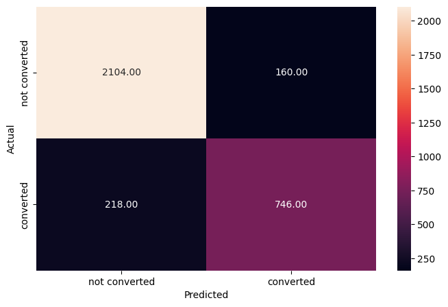

```python
#XGBC tuned train
y_pred_train_xgbc = xgbc_tuned.predict(X_train)
metrics_score(y_train, y_pred_train_xgbc)
```

```
              precision    recall  f1-score   support

           0       0.90      0.91      0.91       971
           1       0.79      0.76      0.77       413

    accuracy                           0.87      1384
   macro avg       0.84      0.84      0.84      1384
weighted avg       0.87      0.87      0.87      1384
```

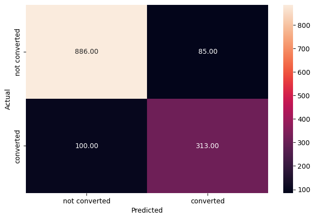

```python
# Checking performance on the testing data
y_pred_test_xgbc = xgbc_tuned.predict(X_test)
metrics_score(y_test, y_pred_test_xgbc)
```

Observations:

- Post performance tuning model performance is improved.
- Based on the recall & precision score XGBoostClassifier is able to generalize better.

```python
type(df.columns)
```

```
pandas.core.indexes.base.Index
```

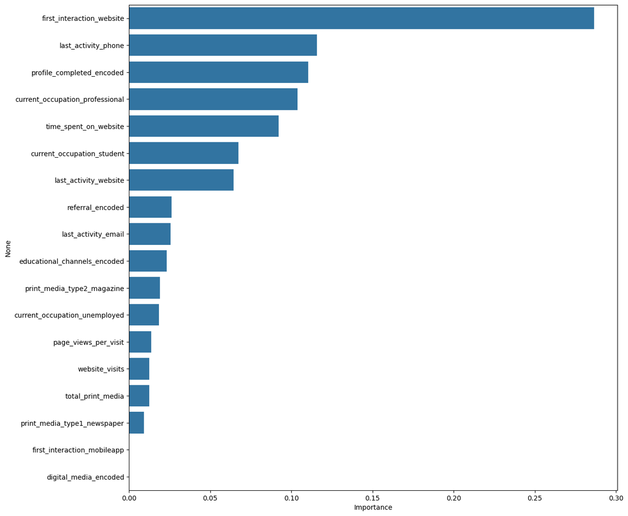

```python
#feature importance of xgboost tuned.
# Plotting feature importance

importances_xgbc = xgbc_tuned.feature_importances_ #ndarray

columns = df.drop(columns=['status']).columns #type - <class 'pandas.core.indexes.base.Index'>

importance_df_xgbc = pd.DataFrame(importances_xgbc, index = columns, columns = ['Importance']).sort_values(by = 'Importance', ascending = False)

plt.figure(figsize = (13, 13))

sns.barplot(x= importance_df_xgbc.Importance, y= importance_df_xgbc.index)

plt.show()
```

```python
from sklearn.metrics import precision_score, recall_score, accuracy_score

def compute_model_metrics(model, feature_var, y_true):

  # feature_var - feature variables / independet variables

  # actual_var - target / ground

  """
    function to compute different metrics to check classification model performance
    and collate them in a dataframe

    model: classifier

    feature_var: independent variables

    y_true: dependent variable
  """

  #predicting using the independent variables

  y_pred = model.predict(feature_var)

  recall = recall_score(y_true=y_true, y_pred = y_pred, average='macro')

  precision = precision_score(y_true=y_true, y_pred = y_pred, average='macro')

  accuracy = accuracy_score(y_true=y_true, y_pred = y_pred)

  # acc = accuracy_score(y_true=y_true, y_pred = y_pred

  df_metrics = pd.DataFrame(
      {
          "Precision":  precision,
          "Recall":  recall,
          "Accuracy": accuracy,
      },
      index = [0]
  )

  return df_metrics
```

```python
# Metrics - model comparision

dtree_estimator_metrics = compute_model_metrics(dtree_estimator, X_test, y_test)

rf_estimator_tuned_metrics = compute_model_metrics(rf_estimator_tuned, X_test, y_test)

adaboost_model_metrics = compute_model_metrics(adaboost_model, X_test, y_test)

gradboost_model_metrics = compute_model_metrics(gradboost_model, X_test, y_test)

xgbc_tuned_metrics = compute_model_metrics(xgbc_tuned, X_test, y_test)



collated_metrics = pd.concat(

          [dtree_estimator_metrics.T,
           rf_estimator_tuned_metrics.T,
           adaboost_model_metrics.T,
           gradboost_model_metrics.T,
           xgbc_tuned_metrics.T
           ],
          axis=1
)

collated_metrics.columns = [
    'Decision_Tree_clss',
    'Random_Forest_clss',
    'Adaboost_clss',
    'Gradientboost_clss',
    'XGBoost_clss'
]

print('---'*50)
print(collated_metrics)
```

```
------------------------------------------------------------------------------------------------------------------------------------------------------
           Decision_Tree_clss  Random_Forest_clss  Adaboost_clss  \
Precision            0.779654            0.831038       0.794115
Recall               0.828658            0.842873       0.772781
Accuracy             0.800578            0.860549       0.823699

           Gradientboost_clss  XGBoost_clss
Precision            0.842434      0.842506
Recall               0.832563      0.835165
Accuracy             0.865607      0.866329
```

## Top 5 five features of the models as per the order above:

XGBoost Classifier

- first_interaction_website
- last_activity_phone
- profile_completed_encoded
- current_occupation_professional
- time_spent_on_website

Decision Tree

- time_spent_on_website
- first_interaction_website
- profile_completed_encoded
- last_activity_phone
- last_activity_website

Random Forest

- time_spent_on_website
- profile_completed_encoded
- first_interaction_website
- first_interaction_mobileapp
- page_views_per_visit

Key differences between sklearn GradientBoostingClassifier and XGBClassifier:

- Regularization: XGBoost includes built-in regularization (L1 and L2) which helps prevent overfitting and improves generalization. Scikit-learn's implementation has fewer regularization options.
- Handling Missing Values: XGBoost has a more sophisticated way of handling missing values by learning the best direction to go when a split encounters a missing value. Scikit-learn's implementation requires explicit handling of missing values (e.g., imputation).
- Speed and Performance: XGBoost is generally faster and more efficient due to optimized algorithms and parallel processing capabilities.
- Features and Functionality: XGBoost offers more advanced features like built-in cross-validation, early stopping, and the ability to handle different objective functions.

Regularization (reference): *Without regularization: The model tries to fit the training data perfectly, even if it means using very complex patterns that won't generalize to new data. It's like trying to draw a line that goes through every single point in a scatter plot, even the outliers, resulting in a wiggly, complex line.*

*With L1 (Lasso) regularization: This technique adds a penalty to the model's complexity based on the absolute values of the model's coefficients (the weights it assigns to each feature). This penalty encourages the model to use fewer features and can even set some coefficients to zero, effectively performing feature selection. It's like drawing a simpler line that captures the general trend without being overly influenced by individual points.*

*With L2 (Ridge) regularization: This technique adds a penalty based on the squared values of the model's coefficients. This penalty encourages the model to use smaller coefficients overall, distributing the weight more evenly across features. It's like drawing a smooth curve that minimizes the impact of any single point, resulting in a more stable line.*

## Actionable Insights and Recommendations

**Recommendations:**

- Seasonal Discount can be offered to boost the lead conversion.
- Custom learning offer can be provided to batch of leads.
- Discount can be granted to lead referrals and value-relationship customer.
- Enable efficient touchpoints improving marketing via digital & other communication channels.

**Factors driving the lead conversion process**

- Website Interaction : Leads spending time on the website in understanding the learning content.
- Profile Completion: Leads filling up the profile info completely or majority of it.
- Time spent on website is also an important feature.
- Page views by Professional and Students about learning content.

**Profile of the leads which are likely to convert**

- Occupation: Professional / Unemployed / Student
- Age: Min 18. 25% in dataset is 36 and less. 50% in dataset is 51 and less. 75% in dataset is 57 and less. Max age is 63.
- Website visits: At least 3 time average and maximum of 30.
- Timespent on website: 150 / 1337 / 2537 secs.
- Page Views: At least 3 pages and maximum of 18.

```python
!pip install nbconvert
```

```python
print(file_dir)
```

```
/content/drive/MyDrive/adsp_laiedm/elective_projects/Elective Project: Data Analysis and Visualization/potential_customers_prediction/
```

```python
! jupyter nbconvert --to html  '/content/drive/MyDrive/adsp_laiedm/elective_projects/Elective Project: Data Analysis and Visualization/potential_customers_prediction/Learner Notebook - Full Code Version - Potential Customers Prediction_v3.ipynb'
```